# Lupus_SLEDAI

# Objetivos

- Correlacionar a escala SLEDAI com os metabolitos;
- Verificar se é possivel identificar diferenças entre as fases ativa e remissão para o LESJ;

# Hipoteses

**Pacientes de LESJ se diferenciam de acordo com o SLEDAI**

Pouca diferença foi observada na pratica, na maioria das analises os grupos não se separam e apenas um metabolito/sinal (VLDL/LDL) apresentou se correlacionar com o score do SLEDAI.

**A mistura entre pacientes em remissão e em fase ativa influência na analise.**

Retirando os pacientes em remissão foi possivel observar uma pequena melhora na separação, mas nenhum efeito acentuado foi observado, apenas uma ligeira mudança na sobreposição dos grupos.

# Analise inicial entre os grupos

```
Data was normalized by: Normalization to sample median | N/A transformation | and Pareto scaling
```

```
PCA
75 samples x 16 variables
standard scaling of predictors
      R2X(cum) pre ort
Total    0.615   2   0
```

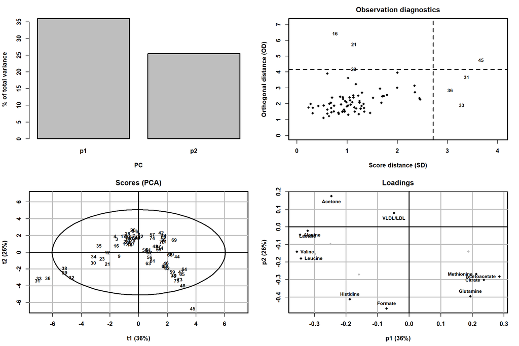

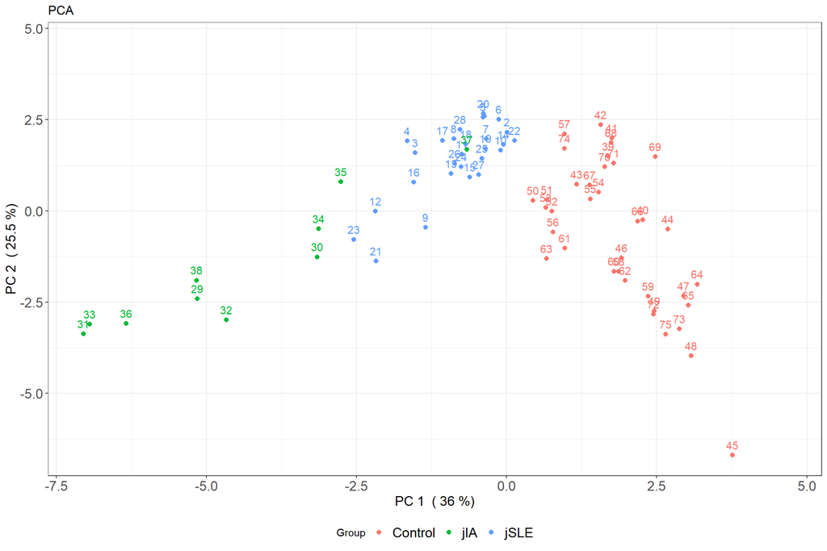

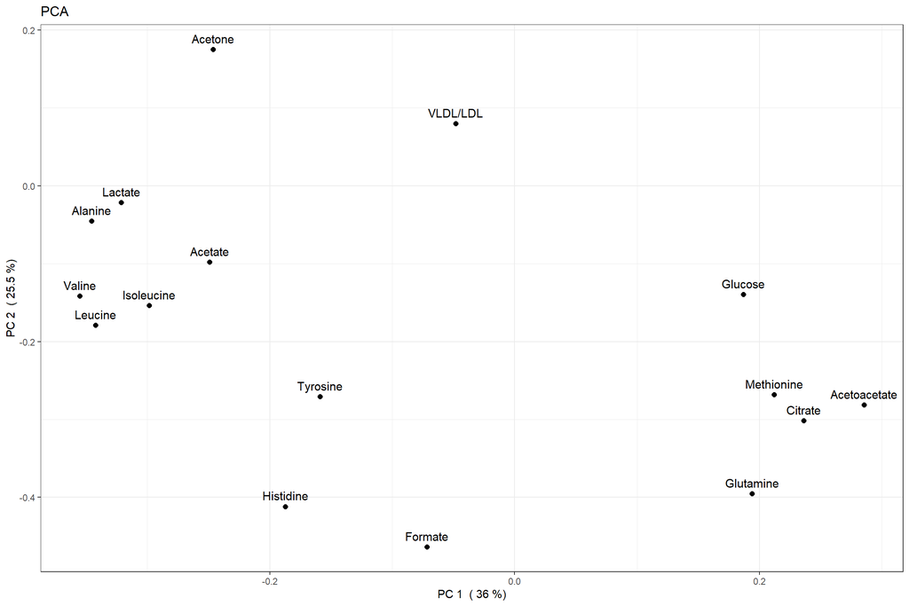

Mesmo na PCA os grupos LESJ e AIJ se separam do controle.

```
PLS-DA
75 samples x 16 variables and 1 response
standard scaling of predictors and response(s)
      R2X(cum) R2Y(cum) Q2(cum) RMSEE pre ort pR2Y  pQ2
Total    0.806    0.844   0.797 0.178   4   0 0.05 0.05
```

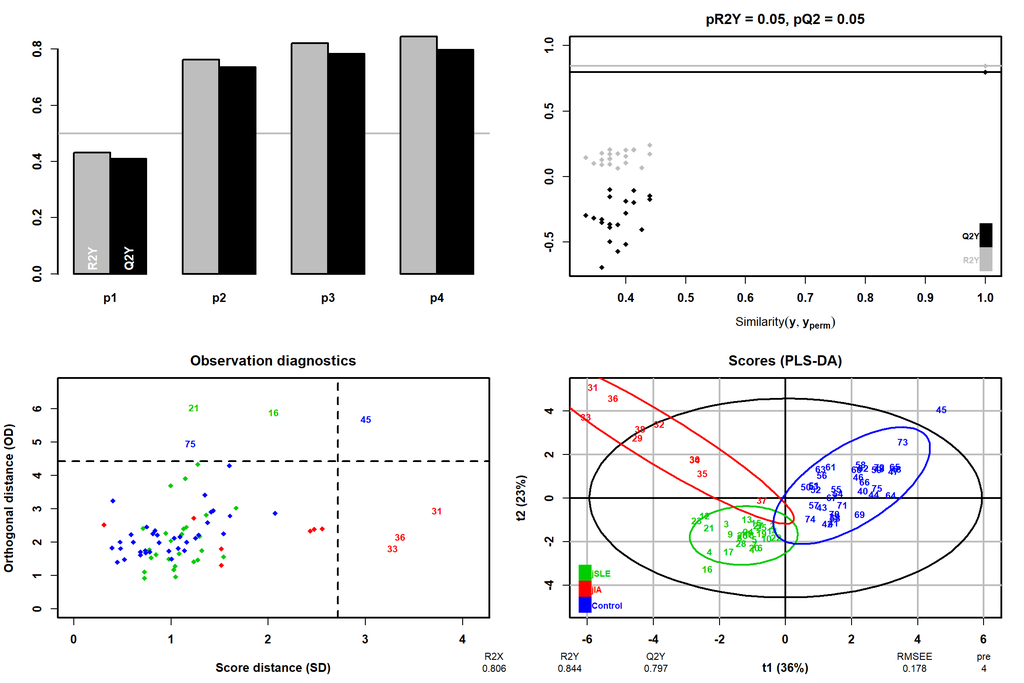

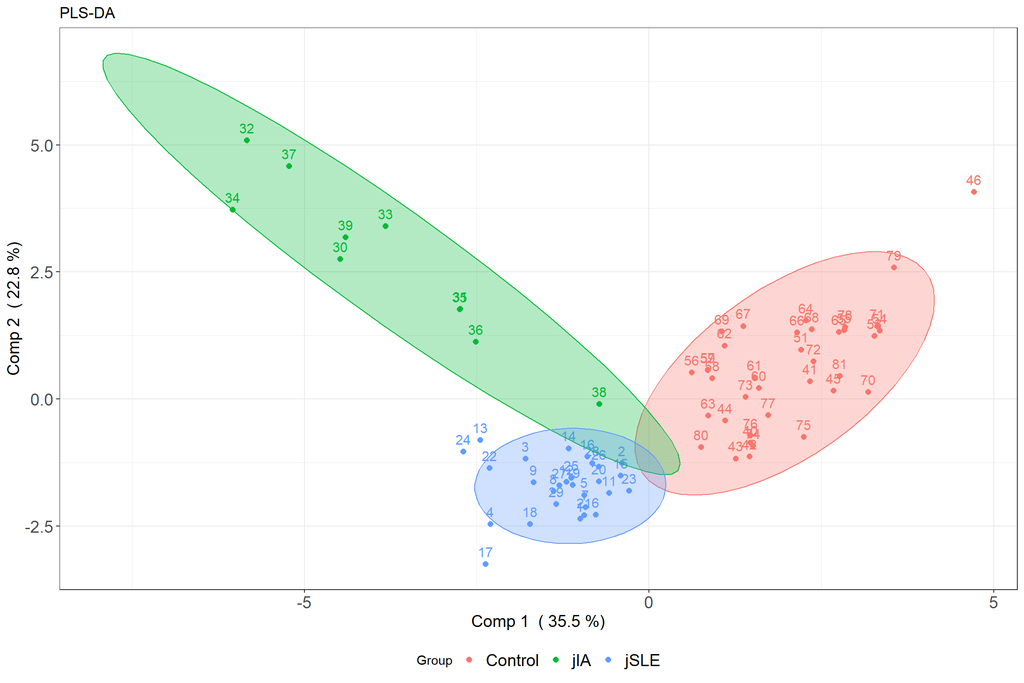

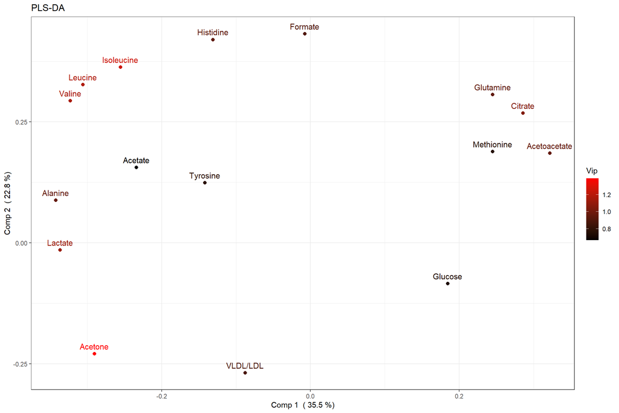

Apesar da dispersão grande no grupo AIJ o modelo de PLS-DA caracteriza bem os 3 grupos, além de apresentar um modelo robusto com bons parametros de validação.

Para verificar se a inclusão dos pacientes em remissão impacta na analise, no modelo a seguir foi filtrado os pacientes de LESJ em remissão de acordo com o SLEDAI.

```
PLS-DA
69 samples x 16 variables and 1 response
standard scaling of predictors and response(s)
      R2X(cum) R2Y(cum) Q2(cum) RMSEE pre ort pR2Y  pQ2
Total     0.81    0.852   0.807 0.172   4   0 0.05 0.05
```

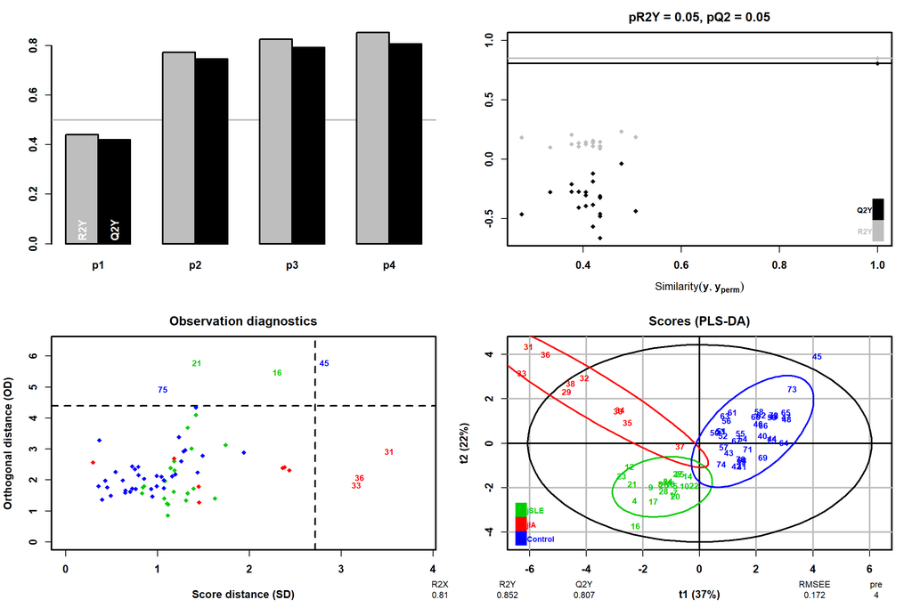

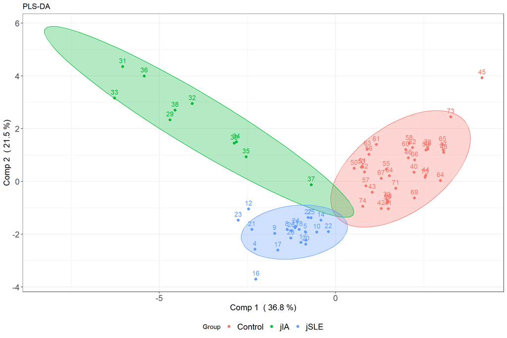

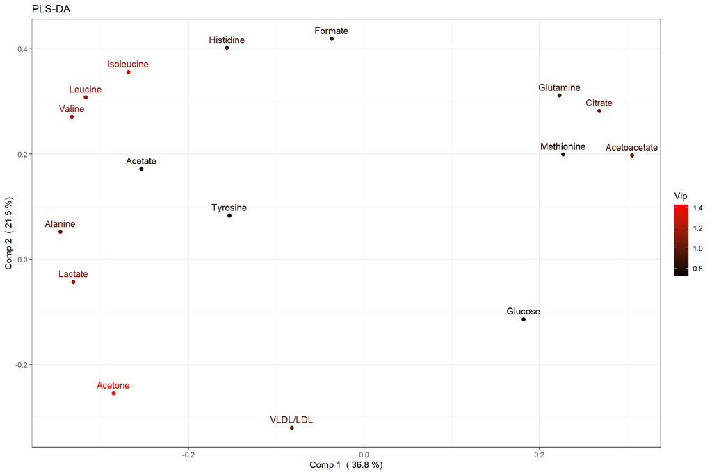

Comparando apenas LESJ e AIJ, ainda filtrando para retirar as amostras dos pacientes em remissão para LESJ.

```
PLS-DA
32 samples x 16 variables and 1 response
standard scaling of predictors and response(s)
      R2X(cum) R2Y(cum) Q2(cum) RMSEE pre ort pR2Y  pQ2
Total    0.605    0.859   0.806 0.183   2   0 0.05 0.05
```

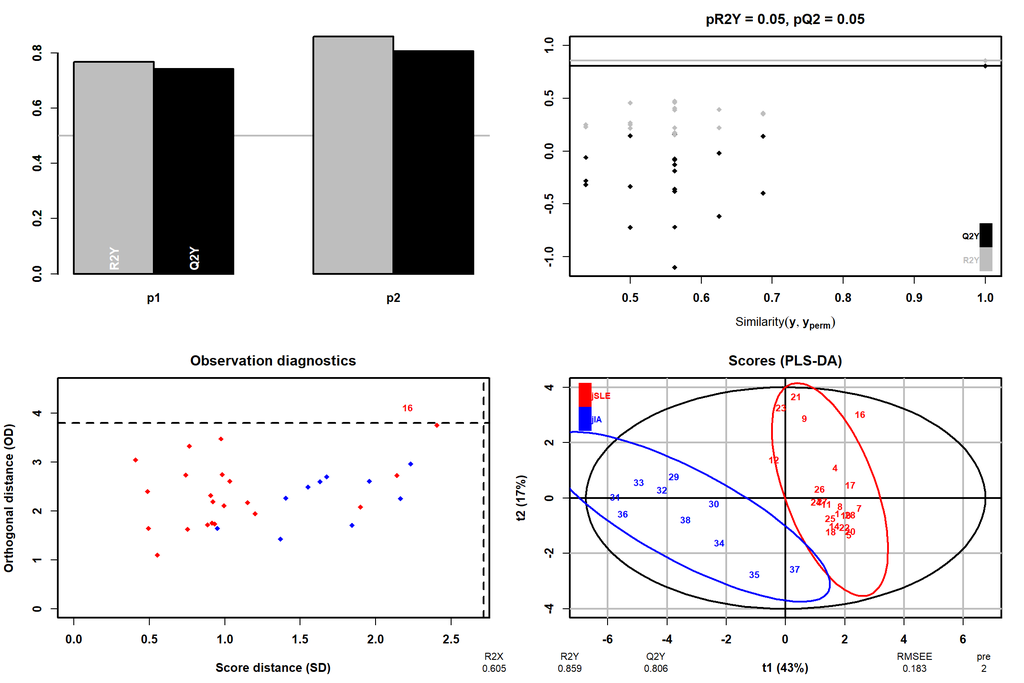

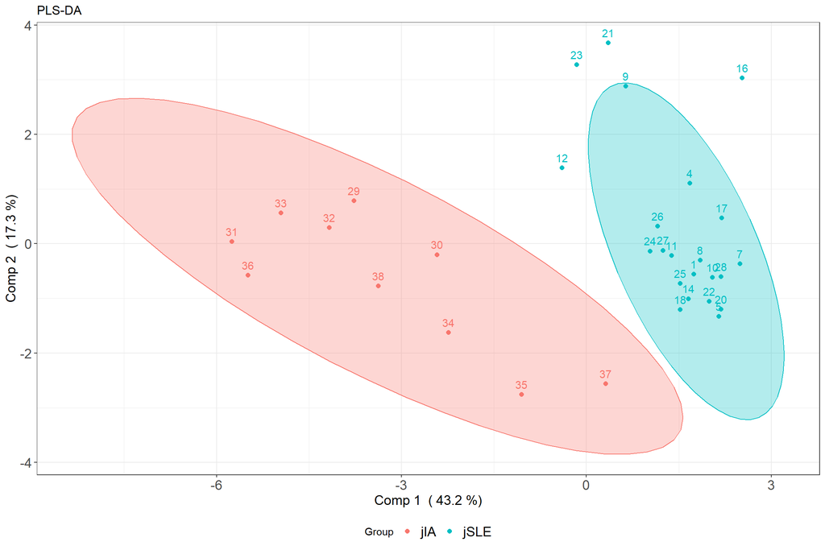

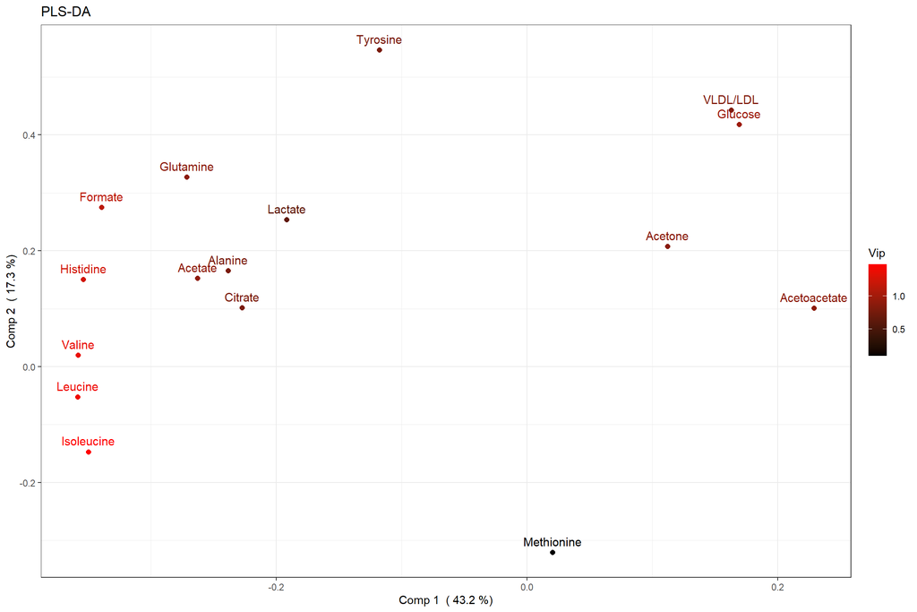

Em comparação com as demais analises, remover os pacientes em remissão causa uma ligeira melhora na separação entre o grupo LESJ dos grupos AIJ e control.

# Comparação dos subgrupos com base no SLEDAI

| Label | SLEDAI2K (10 dias antes da coleta) | n |
| --- | --- | --- |
| Control | NA | 37 |
| jIA | NA | 10 |
| jSLE | 0 | 6 |
| jSLE | 1 | 1 |
| jSLE | 2 | 1 |
| jSLE | 3 | 1 |
| jSLE | 4 | 8 |
| jSLE | 8 | 1 |
| jSLE | 13 | 1 |
| jSLE | 16 | 4 |
| jSLE | 19 | 1 |
| jSLE | 22 | 1 |
| jSLE | 23 | 1 |
| jSLE | 33 | 1 |
| jSLE | NA | 1 |

Há poucos pacientes de LESJ que podem ser classificado como remissão (SLEDAI-2K = 0) em comparação com os pacientes em fase ativa. Por hora, vou usar o criterio do artigo abaixo para tentar balancear melhor os grupos, embora ainda exista apenas uma amostra (SLEDAI=8) que se encaixa no criterio “moderate” que foi realocada para o grupo “severe”.

*According to Carter et al., one can divide SLE activity based on SLEDAI-2K into severe (SLEDAI-2K > 12), moderate (6 < SLEDAI-2K ≤ 12), mild (0 < SLEDAI-2K ≤ 6) and remission (SLEDAI-2K = 0)*

[Suszek et al (2024)](https://pmc.ncbi.nlm.nih.gov/articles/PMC11267658/)

Filtrando apenas o grupo LESJ para verificar a distribuição de acordo com o SLEDAI.

```
PCA
27 samples x 16 variables
standard scaling of predictors
      R2X(cum) pre ort
Total    0.924   8   0
```

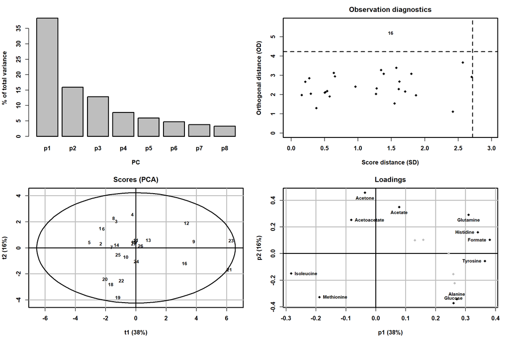

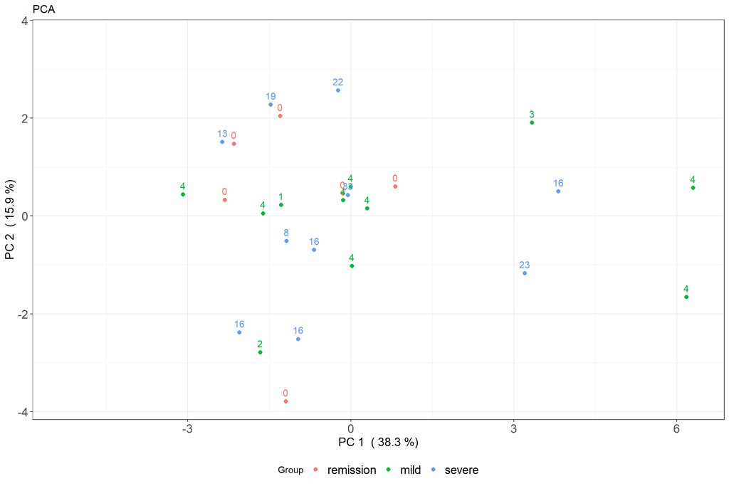

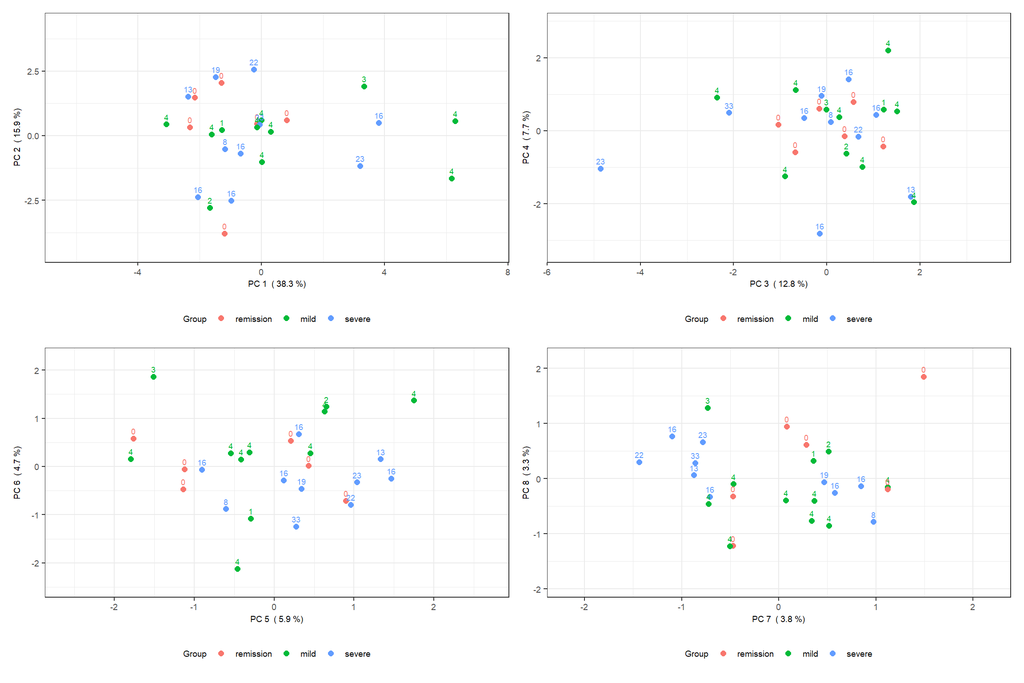

Os grupos em remissão, leve e severo não se separam nem por PCA ou PLS-DA (Modelo não significativo). Testando cada metabolito individualmente, nenhum dos metabolitos apresentou diferença significativa na Anova entre os grupos com base no SLEDAI. Também foi verificado se alguns dos metabolitos apresentaria significancia testando somente os grupos remission e severe, nesse caso apenas a **isoleucina** apresentou significância se desconsiderada a correção por FDR, portanto existe o risco de ser apenas um falso positivo do teste.

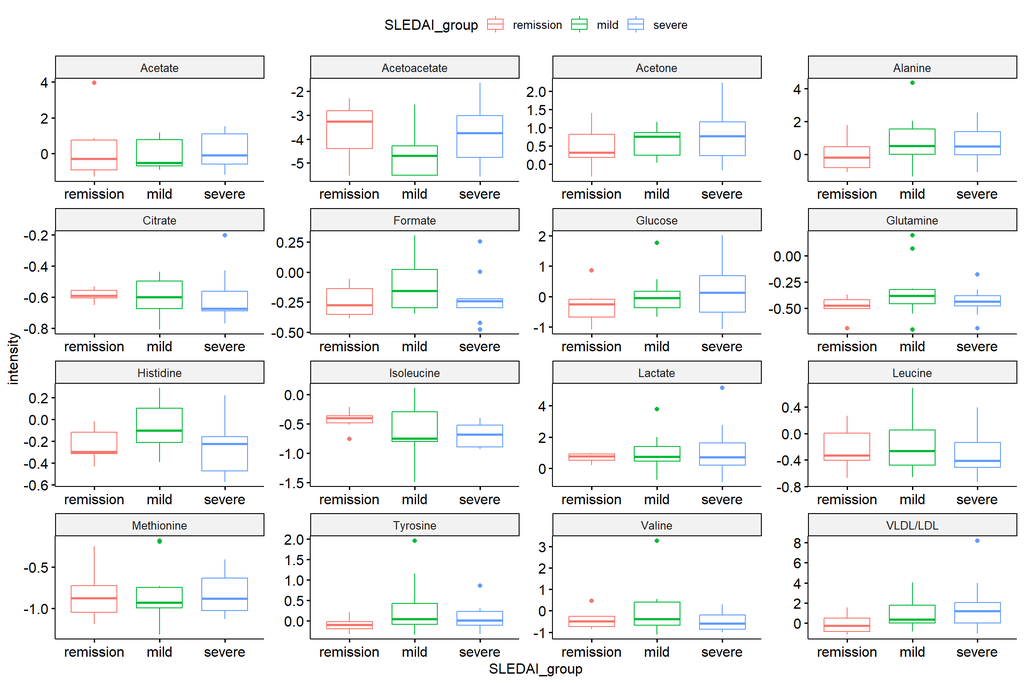

Uma possivel variável de confusão aqui é o uso de medicamentos, todos os pacientes de LESJ independente do SLEDAI fazem uso de hidroxicloroquina associada a alguns outros imunosupressores em alguns casos, ficando dificil diferenciar os efeitos do uso do medicamento dos efeitos da condição.

O boxplot mostra um pequeno aumento do VLDL em função dos grupos do SLEDAI, apesar de que não foi observado significancia na diferença entre as média dos grupos, uma correlação significativa foi observada entre **VLDL** e o valor do SLEDAI (r=0.41, p=0.033).

Testando a correlação entre os metabolitos e os parametros SLEDAI

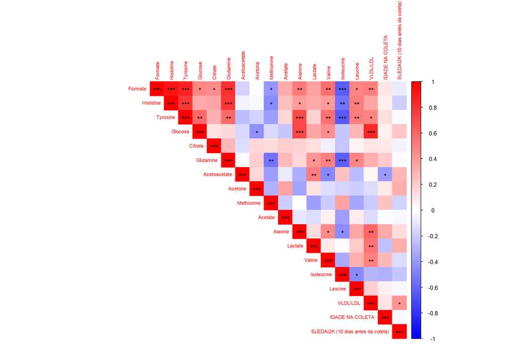

Além do VLDL nenhum outro metabolito apresentou correlação significativa com os valores de SLEDAI.

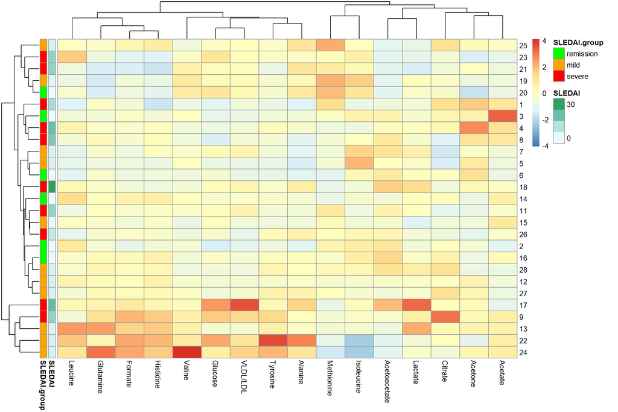